# Risk Factor Analysis

## Outcome Variable

**Outcome Variable:** swasted

## Predictor Variables

**Intervention Variable:** meducyrs

**Adjustment Set:**

- arm
- W_mage
- feducyrs
- W_mhtcm
- W_gagebrth
- W_birthwt
- W_birthlen
- single
- impsan
- delta_W_mage
- delta_feducyrs
- delta_W_mhtcm
- delta_W_gagebrth
- delta_W_birthwt
- delta_W_birthlen
- delta_single
- delta_impsan

## Stratifying Variables

The analysis was stratified on these variable(s):

- agecat
- studyid
- country

## Data Summary

| agecat | studyid | country | meducyrs | swasted | n_cell | n |
| --- | --- | --- | --- | --- | --- | --- |
| Birth | ki0047075b-MAL-ED | BANGLADESH | High | 0 | 71 | 195 |
| Birth | ki0047075b-MAL-ED | BANGLADESH | High | 1 | 1 | 195 |
| Birth | ki0047075b-MAL-ED | BANGLADESH | Low | 0 | 61 | 195 |
| Birth | ki0047075b-MAL-ED | BANGLADESH | Low | 1 | 2 | 195 |
| Birth | ki0047075b-MAL-ED | BANGLADESH | Medium | 0 | 57 | 195 |
| Birth | ki0047075b-MAL-ED | BANGLADESH | Medium | 1 | 3 | 195 |
| Birth | ki0047075b-MAL-ED | BRAZIL | High | 0 | 63 | 182 |
| Birth | ki0047075b-MAL-ED | BRAZIL | High | 1 | 0 | 182 |
| Birth | ki0047075b-MAL-ED | BRAZIL | Low | 0 | 51 | 182 |
| Birth | ki0047075b-MAL-ED | BRAZIL | Low | 1 | 0 | 182 |
| Birth | ki0047075b-MAL-ED | BRAZIL | Medium | 0 | 68 | 182 |
| Birth | ki0047075b-MAL-ED | BRAZIL | Medium | 1 | 0 | 182 |
| Birth | ki0047075b-MAL-ED | INDIA | High | 0 | 50 | 180 |
| Birth | ki0047075b-MAL-ED | INDIA | High | 1 | 1 | 180 |
| Birth | ki0047075b-MAL-ED | INDIA | Low | 0 | 59 | 180 |
| Birth | ki0047075b-MAL-ED | INDIA | Low | 1 | 1 | 180 |
| Birth | ki0047075b-MAL-ED | INDIA | Medium | 0 | 64 | 180 |
| Birth | ki0047075b-MAL-ED | INDIA | Medium | 1 | 5 | 180 |
| Birth | ki0047075b-MAL-ED | NEPAL | High | 0 | 36 | 155 |
| Birth | ki0047075b-MAL-ED | NEPAL | High | 1 | 1 | 155 |
| Birth | ki0047075b-MAL-ED | NEPAL | Low | 0 | 65 | 155 |
| Birth | ki0047075b-MAL-ED | NEPAL | Low | 1 | 0 | 155 |
| Birth | ki0047075b-MAL-ED | NEPAL | Medium | 0 | 51 | 155 |
| Birth | ki0047075b-MAL-ED | NEPAL | Medium | 1 | 2 | 155 |
| Birth | ki0047075b-MAL-ED | PERU | High | 0 | 82 | 278 |
| Birth | ki0047075b-MAL-ED | PERU | High | 1 | 0 | 278 |
| Birth | ki0047075b-MAL-ED | PERU | Low | 0 | 98 | 278 |
| Birth | ki0047075b-MAL-ED | PERU | Low | 1 | 0 | 278 |
| Birth | ki0047075b-MAL-ED | PERU | Medium | 0 | 98 | 278 |
| Birth | ki0047075b-MAL-ED | PERU | Medium | 1 | 0 | 278 |

[output cut: 378 more lines]

The following strata were considered:

- agecat: 24 months, studyid: ki0047075b-MAL-ED, country: BANGLADESH
- agecat: 24 months, studyid: ki0047075b-MAL-ED, country: BRAZIL
- agecat: 24 months, studyid: ki0047075b-MAL-ED, country: INDIA
- agecat: 24 months, studyid: ki0047075b-MAL-ED, country: NEPAL
- agecat: 24 months, studyid: ki0047075b-MAL-ED, country: PERU
- agecat: 24 months, studyid: ki0047075b-MAL-ED, country: SOUTH AFRICA
- agecat: 24 months, studyid: ki0047075b-MAL-ED, country: TANZANIA, UNITED REPUBLIC OF
- agecat: 24 months, studyid: ki1000108-CMC-V-BCS-2002, country: INDIA
- agecat: 24 months, studyid: ki1000108-IRC, country: INDIA
- agecat: 24 months, studyid: ki1017093-NIH-Birth, country: BANGLADESH
- agecat: 24 months, studyid: ki1017093b-PROVIDE, country: BANGLADESH
- agecat: 24 months, studyid: ki1017093c-NIH-Crypto, country: BANGLADESH
- agecat: 24 months, studyid: ki1066203-TanzaniaChild2, country: TANZANIA, UNITED REPUBLIC OF
- agecat: 24 months, studyid: ki1113344-GMS-Nepal, country: NEPAL
- agecat: 24 months, studyid: ki1119695-PROBIT, country: BELARUS
- agecat: 24 months, studyid: ki1126311-ZVITAMBO, country: ZIMBABWE
- agecat: 24 months, studyid: ki1135781-COHORTS, country: GUATEMALA
- agecat: 24 months, studyid: ki1135781-COHORTS, country: INDIA
- agecat: 24 months, studyid: ki1135781-COHORTS, country: PHILIPPINES
- agecat: 24 months, studyid: ki1148112-LCNI-5, country: MALAWI
- agecat: 24 months, studyid: kiGH5241-JiVitA-3, country: BANGLADESH
- agecat: 24 months, studyid: kiGH5241-JiVitA-4, country: BANGLADESH
- agecat: 6 months, studyid: ki0047075b-MAL-ED, country: BANGLADESH
- agecat: 6 months, studyid: ki0047075b-MAL-ED, country: BRAZIL
- agecat: 6 months, studyid: ki0047075b-MAL-ED, country: INDIA
- agecat: 6 months, studyid: ki0047075b-MAL-ED, country: NEPAL
- agecat: 6 months, studyid: ki0047075b-MAL-ED, country: PERU
- agecat: 6 months, studyid: ki0047075b-MAL-ED, country: SOUTH AFRICA
- agecat: 6 months, studyid: ki0047075b-MAL-ED, country: TANZANIA, UNITED REPUBLIC OF
- agecat: 6 months, studyid: ki1000108-CMC-V-BCS-2002, country: INDIA
- agecat: 6 months, studyid: ki1000108-IRC, country: INDIA
- agecat: 6 months, studyid: ki1000109-EE, country: PAKISTAN
- agecat: 6 months, studyid: ki1000304b-SAS-CompFeed, country: INDIA
- agecat: 6 months, studyid: ki1000304b-SAS-FoodSuppl, country: INDIA
- agecat: 6 months, studyid: ki1017093-NIH-Birth, country: BANGLADESH
- agecat: 6 months, studyid: ki1017093b-PROVIDE, country: BANGLADESH
- agecat: 6 months, studyid: ki1017093c-NIH-Crypto, country: BANGLADESH
- agecat: 6 months, studyid: ki1066203-TanzaniaChild2, country: TANZANIA, UNITED REPUBLIC OF
- agecat: 6 months, studyid: ki1112895-Guatemala BSC, country: GUATEMALA
- agecat: 6 months, studyid: ki1113344-GMS-Nepal, country: NEPAL
- agecat: 6 months, studyid: ki1119695-PROBIT, country: BELARUS
- agecat: 6 months, studyid: ki1126311-ZVITAMBO, country: ZIMBABWE
- agecat: 6 months, studyid: ki1135781-COHORTS, country: GUATEMALA
- agecat: 6 months, studyid: ki1135781-COHORTS, country: INDIA
- agecat: 6 months, studyid: ki1135781-COHORTS, country: PHILIPPINES
- agecat: 6 months, studyid: ki1148112-LCNI-5, country: MALAWI
- agecat: 6 months, studyid: kiGH5241-JiVitA-3, country: BANGLADESH
- agecat: 6 months, studyid: kiGH5241-JiVitA-4, country: BANGLADESH
- agecat: Birth, studyid: ki0047075b-MAL-ED, country: BANGLADESH
- agecat: Birth, studyid: ki0047075b-MAL-ED, country: BRAZIL
- agecat: Birth, studyid: ki0047075b-MAL-ED, country: INDIA
- agecat: Birth, studyid: ki0047075b-MAL-ED, country: NEPAL
- agecat: Birth, studyid: ki0047075b-MAL-ED, country: PERU
- agecat: Birth, studyid: ki0047075b-MAL-ED, country: SOUTH AFRICA
- agecat: Birth, studyid: ki0047075b-MAL-ED, country: TANZANIA, UNITED REPUBLIC OF
- agecat: Birth, studyid: ki1000108-CMC-V-BCS-2002, country: INDIA
- agecat: Birth, studyid: ki1000108-IRC, country: INDIA
- agecat: Birth, studyid: ki1000109-EE, country: PAKISTAN
- agecat: Birth, studyid: ki1000304b-SAS-CompFeed, country: INDIA
- agecat: Birth, studyid: ki1017093-NIH-Birth, country: BANGLADESH
- agecat: Birth, studyid: ki1017093c-NIH-Crypto, country: BANGLADESH
- agecat: Birth, studyid: ki1119695-PROBIT, country: BELARUS
- agecat: Birth, studyid: ki1126311-ZVITAMBO, country: ZIMBABWE
- agecat: Birth, studyid: ki1135781-COHORTS, country: GUATEMALA
- agecat: Birth, studyid: ki1135781-COHORTS, country: INDIA
- agecat: Birth, studyid: ki1135781-COHORTS, country: PHILIPPINES
- agecat: Birth, studyid: kiGH5241-JiVitA-3, country: BANGLADESH
- agecat: Birth, studyid: kiGH5241-JiVitA-4, country: BANGLADESH

### Dropped Strata

Some strata were dropped due to rare outcomes:

- agecat: Birth, studyid: ki0047075b-MAL-ED, country: BANGLADESH
- agecat: Birth, studyid: ki0047075b-MAL-ED, country: BRAZIL
- agecat: Birth, studyid: ki0047075b-MAL-ED, country: INDIA
- agecat: Birth, studyid: ki0047075b-MAL-ED, country: NEPAL
- agecat: Birth, studyid: ki0047075b-MAL-ED, country: PERU
- agecat: Birth, studyid: ki0047075b-MAL-ED, country: SOUTH AFRICA
- agecat: Birth, studyid: ki0047075b-MAL-ED, country: TANZANIA, UNITED REPUBLIC OF
- agecat: Birth, studyid: ki1000108-CMC-V-BCS-2002, country: INDIA
- agecat: Birth, studyid: ki1000109-EE, country: PAKISTAN
- agecat: Birth, studyid: ki1000304b-SAS-CompFeed, country: INDIA
- agecat: Birth, studyid: ki1017093-NIH-Birth, country: BANGLADESH
- agecat: Birth, studyid: ki1017093c-NIH-Crypto, country: BANGLADESH
- agecat: Birth, studyid: kiGH5241-JiVitA-4, country: BANGLADESH
- agecat: 6 months, studyid: ki0047075b-MAL-ED, country: BANGLADESH
- agecat: 6 months, studyid: ki0047075b-MAL-ED, country: BRAZIL
- agecat: 6 months, studyid: ki0047075b-MAL-ED, country: INDIA
- agecat: 6 months, studyid: ki0047075b-MAL-ED, country: NEPAL
- agecat: 6 months, studyid: ki0047075b-MAL-ED, country: PERU
- agecat: 6 months, studyid: ki0047075b-MAL-ED, country: SOUTH AFRICA
- agecat: 6 months, studyid: ki0047075b-MAL-ED, country: TANZANIA, UNITED REPUBLIC OF
- agecat: 6 months, studyid: ki1000108-CMC-V-BCS-2002, country: INDIA
- agecat: 6 months, studyid: ki1000109-EE, country: PAKISTAN
- agecat: 6 months, studyid: ki1000304b-SAS-CompFeed, country: INDIA
- agecat: 6 months, studyid: ki1000304b-SAS-FoodSuppl, country: INDIA
- agecat: 6 months, studyid: ki1017093-NIH-Birth, country: BANGLADESH
- agecat: 6 months, studyid: ki1017093b-PROVIDE, country: BANGLADESH
- agecat: 6 months, studyid: ki1017093c-NIH-Crypto, country: BANGLADESH
- agecat: 6 months, studyid: ki1066203-TanzaniaChild2, country: TANZANIA, UNITED REPUBLIC OF
- agecat: 6 months, studyid: ki1112895-Guatemala BSC, country: GUATEMALA
- agecat: 6 months, studyid: ki1113344-GMS-Nepal, country: NEPAL
- agecat: 6 months, studyid: ki1119695-PROBIT, country: BELARUS
- agecat: 6 months, studyid: ki1135781-COHORTS, country: GUATEMALA
- agecat: 6 months, studyid: ki1148112-LCNI-5, country: MALAWI
- agecat: 6 months, studyid: kiGH5241-JiVitA-4, country: BANGLADESH
- agecat: 24 months, studyid: ki0047075b-MAL-ED, country: BANGLADESH
- agecat: 24 months, studyid: ki0047075b-MAL-ED, country: BRAZIL
- agecat: 24 months, studyid: ki0047075b-MAL-ED, country: INDIA
- agecat: 24 months, studyid: ki0047075b-MAL-ED, country: NEPAL
- agecat: 24 months, studyid: ki0047075b-MAL-ED, country: PERU
- agecat: 24 months, studyid: ki0047075b-MAL-ED, country: SOUTH AFRICA
- agecat: 24 months, studyid: ki0047075b-MAL-ED, country: TANZANIA, UNITED REPUBLIC OF
- agecat: 24 months, studyid: ki1000108-CMC-V-BCS-2002, country: INDIA
- agecat: 24 months, studyid: ki1000108-IRC, country: INDIA
- agecat: 24 months, studyid: ki1017093-NIH-Birth, country: BANGLADESH
- agecat: 24 months, studyid: ki1017093b-PROVIDE, country: BANGLADESH
- agecat: 24 months, studyid: ki1017093c-NIH-Crypto, country: BANGLADESH
- agecat: 24 months, studyid: ki1066203-TanzaniaChild2, country: TANZANIA, UNITED REPUBLIC OF
- agecat: 24 months, studyid: ki1113344-GMS-Nepal, country: NEPAL
- agecat: 24 months, studyid: ki1119695-PROBIT, country: BELARUS
- agecat: 24 months, studyid: ki1135781-COHORTS, country: GUATEMALA
- agecat: 24 months, studyid: ki1135781-COHORTS, country: INDIA
- agecat: 24 months, studyid: ki1148112-LCNI-5, country: MALAWI
- agecat: 24 months, studyid: kiGH5241-JiVitA-4, country: BANGLADESH

## Methods Detail

We’re interested in the causal parameters $E[Y_a]$ for all values of $a \in \mathcal{A}$. These parameters represent the mean outcome if, possibly contrary to fact, we intervened to set all units to have $A=a$. Under the randomization and positivity assumptions, these are identified by the statistical parameters $\psi_a=E_W[E_{Y|A,W}(Y|A=a,W)]$. In addition, we’re interested in the mean of $Y$, $E[Y]$ under no intervention (the observed mean). We will estimate these parameters by using SuperLearner to fit the relevant likelihood factors – $E_{Y|A,W}(Y|A=a,W)$ and $p(A=a|W)$, and then updating our likelihood fit using a joint TMLE.

For unadjusted analyses ($W=\{\}$), initial likelihoods were estimated using Lrnr_glm to estimate the simple $E(Y|A)$ and Lrnr_mean to estimate $p(A)$. For adjusted analyses, a small library containing Lrnr_glmnet, Lrnr_xgboost, and Lrnr_mean was used.

Having estimated these parameters, we will then use the delta method to estimate relative risks and attributable risks relative to a prespecified baseline level of $A$.

# Results Detail

## Results Plots

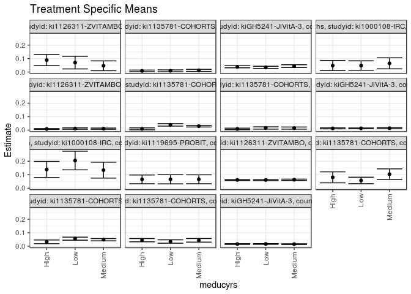

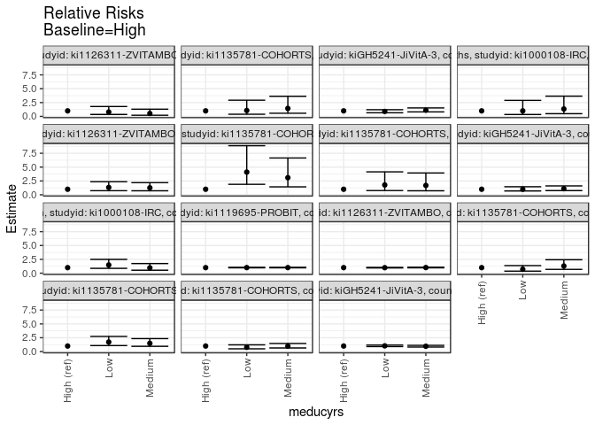

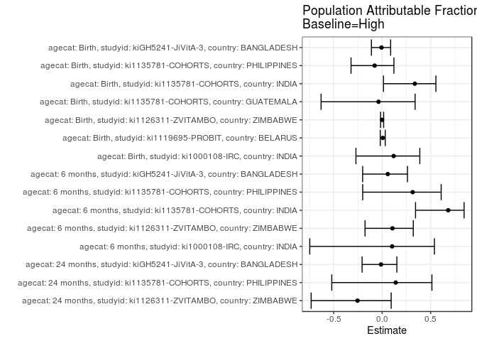

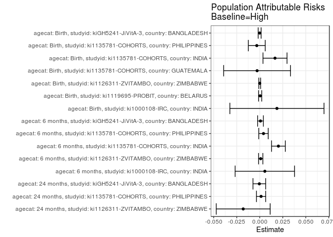

## Results Table

### Parameter: TSM

| agecat | studyid | country | intervention_level | baseline_level | estimate | ci_lower | ci_upper |
| --- | --- | --- | --- | --- | --- | --- | --- |
| Birth | ki1000108-IRC | INDIA | High | NA | 0.1387671 | 0.0790368 | 0.1984975 |
| Birth | ki1000108-IRC | INDIA | Low | NA | 0.2051415 | 0.1359747 | 0.2743084 |
| Birth | ki1000108-IRC | INDIA | Medium | NA | 0.1337938 | 0.0748507 | 0.1927369 |
| Birth | ki1119695-PROBIT | BELARUS | High | NA | 0.0654729 | 0.0330211 | 0.0979246 |
| Birth | ki1119695-PROBIT | BELARUS | Low | NA | 0.0660470 | 0.0321353 | 0.0999587 |
| Birth | ki1119695-PROBIT | BELARUS | Medium | NA | 0.0660218 | 0.0330958 | 0.0989478 |
| Birth | ki1126311-ZVITAMBO | ZIMBABWE | High | NA | 0.0612812 | 0.0570243 | 0.0655380 |
| Birth | ki1126311-ZVITAMBO | ZIMBABWE | Low | NA | 0.0610081 | 0.0563088 | 0.0657074 |
| Birth | ki1126311-ZVITAMBO | ZIMBABWE | Medium | NA | 0.0623691 | 0.0576004 | 0.0671378 |
| Birth | ki1135781-COHORTS | GUATEMALA | High | NA | 0.0804175 | 0.0395830 | 0.1212520 |
| Birth | ki1135781-COHORTS | GUATEMALA | Low | NA | 0.0572025 | 0.0331073 | 0.0812977 |
| Birth | ki1135781-COHORTS | GUATEMALA | Medium | NA | 0.1041148 | 0.0649997 | 0.1432299 |
| Birth | ki1135781-COHORTS | INDIA | High | NA | 0.0326189 | 0.0190054 | 0.0462325 |
| Birth | ki1135781-COHORTS | INDIA | Low | NA | 0.0562026 | 0.0449069 | 0.0674983 |
| Birth | ki1135781-COHORTS | INDIA | Medium | NA | 0.0486425 | 0.0403257 | 0.0569593 |
| Birth | ki1135781-COHORTS | PHILIPPINES | High | NA | 0.0449610 | 0.0328760 | 0.0570461 |
| Birth | ki1135781-COHORTS | PHILIPPINES | Low | NA | 0.0349914 | 0.0224702 | 0.0475125 |
| Birth | ki1135781-COHORTS | PHILIPPINES | Medium | NA | 0.0439921 | 0.0306371 | 0.0573470 |
| Birth | kiGH5241-JiVitA-3 | BANGLADESH | High | NA | 0.0163013 | 0.0134700 | 0.0191325 |
| Birth | kiGH5241-JiVitA-3 | BANGLADESH | Low | NA | 0.0168045 | 0.0141601 | 0.0194488 |
| Birth | kiGH5241-JiVitA-3 | BANGLADESH | Medium | NA | 0.0156324 | 0.0130387 | 0.0182262 |
| 6 months | ki1000108-IRC | INDIA | High | NA | 0.0483871 | 0.0105720 | 0.0862022 |
| 6 months | ki1000108-IRC | INDIA | Low | NA | 0.0482759 | 0.0133443 | 0.0832074 |
| 6 months | ki1000108-IRC | INDIA | Medium | NA | 0.0647482 | 0.0237890 | 0.1057074 |
| 6 months | ki1126311-ZVITAMBO | ZIMBABWE | High | NA | 0.0085578 | 0.0055738 | 0.0115418 |
| 6 months | ki1126311-ZVITAMBO | ZIMBABWE | Low | NA | 0.0113266 | 0.0060801 | 0.0165732 |
| 6 months | ki1126311-ZVITAMBO | ZIMBABWE | Medium | NA | 0.0107905 | 0.0061651 | 0.0154159 |
| 6 months | ki1135781-COHORTS | INDIA | High | NA | 0.0094980 | 0.0024947 | 0.0165012 |
| 6 months | ki1135781-COHORTS | INDIA | Low | NA | 0.0388952 | 0.0298972 | 0.0478931 |
| 6 months | ki1135781-COHORTS | INDIA | Medium | NA | 0.0293508 | 0.0232029 | 0.0354988 |
| 6 months | ki1135781-COHORTS | PHILIPPINES | High | NA | 0.0088670 | 0.0030987 | 0.0146353 |
| 6 months | ki1135781-COHORTS | PHILIPPINES | Low | NA | 0.0157767 | 0.0072669 | 0.0242865 |
| 6 months | ki1135781-COHORTS | PHILIPPINES | Medium | NA | 0.0149942 | 0.0069033 | 0.0230852 |
| 6 months | kiGH5241-JiVitA-3 | BANGLADESH | High | NA | 0.0128642 | 0.0092079 | 0.0165204 |
| 6 months | kiGH5241-JiVitA-3 | BANGLADESH | Low | NA | 0.0129329 | 0.0098716 | 0.0159942 |
| 6 months | kiGH5241-JiVitA-3 | BANGLADESH | Medium | NA | 0.0141618 | 0.0105193 | 0.0178043 |
| 24 months | ki1126311-ZVITAMBO | ZIMBABWE | High | NA | 0.0888889 | 0.0472657 | 0.1305121 |
| 24 months | ki1126311-ZVITAMBO | ZIMBABWE | Low | NA | 0.0701754 | 0.0232290 | 0.1171219 |
| 24 months | ki1126311-ZVITAMBO | ZIMBABWE | Medium | NA | 0.0465116 | 0.0101280 | 0.0828952 |
| 24 months | ki1135781-COHORTS | PHILIPPINES | High | NA | 0.0087816 | 0.0027219 | 0.0148412 |
| 24 months | ki1135781-COHORTS | PHILIPPINES | Low | NA | 0.0093583 | 0.0024568 | 0.0162598 |
| 24 months | ki1135781-COHORTS | PHILIPPINES | Medium | NA | 0.0126582 | 0.0048609 | 0.0204555 |
| 24 months | kiGH5241-JiVitA-3 | BANGLADESH | High | NA | 0.0392164 | 0.0314496 | 0.0469833 |
| 24 months | kiGH5241-JiVitA-3 | BANGLADESH | Low | NA | 0.0349123 | 0.0266817 | 0.0431430 |
| 24 months | kiGH5241-JiVitA-3 | BANGLADESH | Medium | NA | 0.0438080 | 0.0332927 | 0.0543233 |

### Parameter: E(Y)

| agecat | studyid | country | intervention_level | baseline_level | estimate | ci_lower | ci_upper |
| --- | --- | --- | --- | --- | --- | --- | --- |
| Birth | ki1000108-IRC | INDIA | NA | NA | 0.1574344 | 0.1188345 | 0.1960344 |
| Birth | ki1119695-PROBIT | BELARUS | NA | NA | 0.0658999 | 0.0328405 | 0.0989593 |
| Birth | ki1126311-ZVITAMBO | ZIMBABWE | NA | NA | 0.0612593 | 0.0571203 | 0.0653983 |
| Birth | ki1135781-COHORTS | GUATEMALA | NA | NA | 0.0775401 | 0.0583612 | 0.0967191 |
| Birth | ki1135781-COHORTS | INDIA | NA | NA | 0.0491904 | 0.0431214 | 0.0552594 |
| Birth | ki1135781-COHORTS | PHILIPPINES | NA | NA | 0.0417385 | 0.0344572 | 0.0490198 |
| Birth | kiGH5241-JiVitA-3 | BANGLADESH | NA | NA | 0.0161938 | 0.0138266 | 0.0185610 |
| 6 months | ki1000108-IRC | INDIA | NA | NA | 0.0539216 | 0.0319786 | 0.0758646 |
| 6 months | ki1126311-ZVITAMBO | ZIMBABWE | NA | NA | 0.0095746 | 0.0074733 | 0.0116759 |
| 6 months | ki1135781-COHORTS | INDIA | NA | NA | 0.0297762 | 0.0252454 | 0.0343071 |
| 6 months | ki1135781-COHORTS | PHILIPPINES | NA | NA | 0.0129342 | 0.0086762 | 0.0171922 |
| 6 months | kiGH5241-JiVitA-3 | BANGLADESH | NA | NA | 0.0136578 | 0.0115849 | 0.0157307 |
| 24 months | ki1126311-ZVITAMBO | ZIMBABWE | NA | NA | 0.0709220 | 0.0464309 | 0.0954131 |
| 24 months | ki1135781-COHORTS | PHILIPPINES | NA | NA | 0.0102082 | 0.0062264 | 0.0141901 |
| 24 months | kiGH5241-JiVitA-3 | BANGLADESH | NA | NA | 0.0387570 | 0.0344303 | 0.0430837 |

### Parameter: RR

| agecat | studyid | country | intervention_level | baseline_level | estimate | ci_lower | ci_upper |
| --- | --- | --- | --- | --- | --- | --- | --- |
| Birth | ki1000108-IRC | INDIA | High | High | 1.0000000 | 1.0000000 | 1.000000 |
| Birth | ki1000108-IRC | INDIA | Low | High | 1.4783151 | 0.8761500 | 2.494339 |
| Birth | ki1000108-IRC | INDIA | Medium | High | 0.9641604 | 0.5348933 | 1.737927 |
| Birth | ki1119695-PROBIT | BELARUS | High | High | 1.0000000 | 1.0000000 | 1.000000 |
| Birth | ki1119695-PROBIT | BELARUS | Low | High | 1.0087690 | 0.9703146 | 1.048747 |
| Birth | ki1119695-PROBIT | BELARUS | Medium | High | 1.0083836 | 0.9711873 | 1.047004 |
| Birth | ki1126311-ZVITAMBO | ZIMBABWE | High | High | 1.0000000 | 1.0000000 | 1.000000 |
| Birth | ki1126311-ZVITAMBO | ZIMBABWE | Low | High | 0.9955439 | 0.9504757 | 1.042749 |
| Birth | ki1126311-ZVITAMBO | ZIMBABWE | Medium | High | 1.0177536 | 0.9715543 | 1.066150 |
| Birth | ki1135781-COHORTS | GUATEMALA | High | High | 1.0000000 | 1.0000000 | 1.000000 |
| Birth | ki1135781-COHORTS | GUATEMALA | Low | High | 0.7113188 | 0.3694013 | 1.369715 |
| Birth | ki1135781-COHORTS | GUATEMALA | Medium | High | 1.2946778 | 0.6895681 | 2.430783 |
| Birth | ki1135781-COHORTS | INDIA | High | High | 1.0000000 | 1.0000000 | 1.000000 |
| Birth | ki1135781-COHORTS | INDIA | Low | High | 1.7230048 | 1.0843559 | 2.737796 |
| Birth | ki1135781-COHORTS | INDIA | Medium | High | 1.4912359 | 0.9502354 | 2.340246 |
| Birth | ki1135781-COHORTS | PHILIPPINES | High | High | 1.0000000 | 1.0000000 | 1.000000 |
| Birth | ki1135781-COHORTS | PHILIPPINES | Low | High | 0.7782596 | 0.4977335 | 1.216892 |
| Birth | ki1135781-COHORTS | PHILIPPINES | Medium | High | 0.9784489 | 0.6528154 | 1.466513 |
| Birth | kiGH5241-JiVitA-3 | BANGLADESH | High | High | 1.0000000 | 1.0000000 | 1.000000 |
| Birth | kiGH5241-JiVitA-3 | BANGLADESH | Low | High | 1.0308711 | 0.8989714 | 1.182124 |
| Birth | kiGH5241-JiVitA-3 | BANGLADESH | Medium | High | 0.9589712 | 0.8166678 | 1.126071 |
| 6 months | ki1000108-IRC | INDIA | High | High | 1.0000000 | 1.0000000 | 1.000000 |
| 6 months | ki1000108-IRC | INDIA | Low | High | 0.9977011 | 0.3439183 | 2.894314 |
| 6 months | ki1000108-IRC | INDIA | Medium | High | 1.3381295 | 0.4895938 | 3.657299 |
| 6 months | ki1126311-ZVITAMBO | ZIMBABWE | High | High | 1.0000000 | 1.0000000 | 1.000000 |
| 6 months | ki1126311-ZVITAMBO | ZIMBABWE | Low | High | 1.3235512 | 0.7412563 | 2.363269 |
| 6 months | ki1126311-ZVITAMBO | ZIMBABWE | Medium | High | 1.2608969 | 0.7255372 | 2.191288 |
| 6 months | ki1135781-COHORTS | INDIA | High | High | 1.0000000 | 1.0000000 | 1.000000 |
| 6 months | ki1135781-COHORTS | INDIA | Low | High | 4.0951039 | 1.8908265 | 8.869072 |
| 6 months | ki1135781-COHORTS | INDIA | Medium | High | 3.0902230 | 1.4358105 | 6.650932 |
| 6 months | ki1135781-COHORTS | PHILIPPINES | High | High | 1.0000000 | 1.0000000 | 1.000000 |
| 6 months | ki1135781-COHORTS | PHILIPPINES | Low | High | 1.7792611 | 0.7642414 | 4.142369 |
| 6 months | ki1135781-COHORTS | PHILIPPINES | Medium | High | 1.6910163 | 0.7262384 | 3.937462 |
| 6 months | kiGH5241-JiVitA-3 | BANGLADESH | High | High | 1.0000000 | 1.0000000 | 1.000000 |
| 6 months | kiGH5241-JiVitA-3 | BANGLADESH | Low | High | 1.0053445 | 0.6932275 | 1.457988 |
| 6 months | kiGH5241-JiVitA-3 | BANGLADESH | Medium | High | 1.1008711 | 0.7557775 | 1.603537 |
| 24 months | ki1126311-ZVITAMBO | ZIMBABWE | High | High | 1.0000000 | 1.0000000 | 1.000000 |
| 24 months | ki1126311-ZVITAMBO | ZIMBABWE | Low | High | 0.7894737 | 0.3488986 | 1.786389 |
| 24 months | ki1126311-ZVITAMBO | ZIMBABWE | Medium | High | 0.5232558 | 0.2102674 | 1.302135 |
| 24 months | ki1135781-COHORTS | PHILIPPINES | High | High | 1.0000000 | 1.0000000 | 1.000000 |
| 24 months | ki1135781-COHORTS | PHILIPPINES | Low | High | 1.0656751 | 0.3881533 | 2.925812 |
| 24 months | ki1135781-COHORTS | PHILIPPINES | Medium | High | 1.4414557 | 0.5715907 | 3.635109 |
| 24 months | kiGH5241-JiVitA-3 | BANGLADESH | High | High | 1.0000000 | 1.0000000 | 1.000000 |
| 24 months | kiGH5241-JiVitA-3 | BANGLADESH | Low | High | 0.8902471 | 0.6562310 | 1.207715 |
| 24 months | kiGH5241-JiVitA-3 | BANGLADESH | Medium | High | 1.1170830 | 0.8166004 | 1.528134 |

### Parameter: PAR

| agecat | studyid | country | intervention_level | baseline_level | estimate | ci_lower | ci_upper |
| --- | --- | --- | --- | --- | --- | --- | --- |
| Birth | ki1000108-IRC | INDIA | High | NA | 0.0186673 | -0.0324616 | 0.0697962 |
| Birth | ki1119695-PROBIT | BELARUS | High | NA | 0.0004270 | -0.0013360 | 0.0021900 |
| Birth | ki1126311-ZVITAMBO | ZIMBABWE | High | NA | -0.0000218 | -0.0009972 | 0.0009535 |
| Birth | ki1135781-COHORTS | GUATEMALA | High | NA | -0.0028774 | -0.0392005 | 0.0334457 |
| Birth | ki1135781-COHORTS | INDIA | High | NA | 0.0165715 | 0.0034899 | 0.0296530 |
| Birth | ki1135781-COHORTS | PHILIPPINES | High | NA | -0.0032225 | -0.0124069 | 0.0059619 |
| Birth | kiGH5241-JiVitA-3 | BANGLADESH | High | NA | -0.0001074 | -0.0017087 | 0.0014938 |
| 6 months | ki1000108-IRC | INDIA | High | NA | 0.0055345 | -0.0267498 | 0.0378187 |
| 6 months | ki1126311-ZVITAMBO | ZIMBABWE | High | NA | 0.0010168 | -0.0013496 | 0.0033833 |
| 6 months | ki1135781-COHORTS | INDIA | High | NA | 0.0202783 | 0.0127813 | 0.0277752 |
| 6 months | ki1135781-COHORTS | PHILIPPINES | High | NA | 0.0040672 | -0.0010750 | 0.0092095 |
| 6 months | kiGH5241-JiVitA-3 | BANGLADESH | High | NA | 0.0007936 | -0.0023362 | 0.0039235 |
| 24 months | ki1126311-ZVITAMBO | ZIMBABWE | High | NA | -0.0179669 | -0.0472559 | 0.0113221 |
| 24 months | ki1135781-COHORTS | PHILIPPINES | High | NA | 0.0014267 | -0.0035989 | 0.0064523 |
| 24 months | kiGH5241-JiVitA-3 | BANGLADESH | High | NA | -0.0004595 | -0.0073606 | 0.0064417 |

### Parameter: PAF

| agecat | studyid | country | intervention_level | baseline_level | estimate | ci_lower | ci_upper |
| --- | --- | --- | --- | --- | --- | --- | --- |
| Birth | ki1000108-IRC | INDIA | High | NA | 0.1185717 | -0.2702593 | 0.3883802 |
| Birth | ki1119695-PROBIT | BELARUS | High | NA | 0.0064796 | -0.0195907 | 0.0318834 |
| Birth | ki1126311-ZVITAMBO | ZIMBABWE | High | NA | -0.0003567 | -0.0164048 | 0.0154381 |
| Birth | ki1135781-COHORTS | GUATEMALA | High | NA | -0.0371089 | -0.6295926 | 0.3399609 |
| Birth | ki1135781-COHORTS | INDIA | High | NA | 0.3368844 | 0.0137244 | 0.5541588 |
| Birth | ki1135781-COHORTS | PHILIPPINES | High | NA | -0.0772069 | -0.3207729 | 0.1214427 |
| Birth | kiGH5241-JiVitA-3 | BANGLADESH | High | NA | -0.0066343 | -0.1105610 | 0.0875669 |
| 6 months | ki1000108-IRC | INDIA | High | NA | 0.1026393 | -0.7462155 | 0.5388563 |
| 6 months | ki1126311-ZVITAMBO | ZIMBABWE | High | NA | 0.1062003 | -0.1765223 | 0.3209837 |
| 6 months | ki1135781-COHORTS | INDIA | High | NA | 0.6810218 | 0.3441589 | 0.8448601 |
| 6 months | ki1135781-COHORTS | PHILIPPINES | High | NA | 0.3144546 | -0.2005200 | 0.6085259 |
| 6 months | kiGH5241-JiVitA-3 | BANGLADESH | High | NA | 0.0581078 | -0.2009264 | 0.2612695 |
| 24 months | ki1126311-ZVITAMBO | ZIMBABWE | High | NA | -0.2533333 | -0.7319954 | 0.0930435 |
| 24 months | ki1135781-COHORTS | PHILIPPINES | High | NA | 0.1397585 | -0.5193606 | 0.5129429 |
| 24 months | kiGH5241-JiVitA-3 | BANGLADESH | High | NA | -0.0118549 | -0.2067111 | 0.1515364 |